[figure not shown]

[figure not shown]

```r
# file     : hands_on_r_04_statistics_notebook.Rmd
# title    : R入門實作班
# subtitle : 5.可重現報告與專題實作（Capstone）
# author   : Ming-Chang Lee
# date     : 2026.09.06
# YouTube  : https://www.youtube.com/@alan9956
# RWEPA    : http://rwepa.blogspot.tw/
# GitHub   : https://github.com/rwepa
# Email    : alan9956@gmail.com
```

大綱:

可重現報告與專題實作（Capstone）

- 5.1 R Markdown/Quarto：報告結構、程式區塊與輸出格式
- 5.2 參數化報告與自動化輸出（HTML/PDF）
- 5.3 專題題目設計：指標定義、資料流程、視覺化呈現
- 5.4 分組/個人實作：完成小型分析專題
- 5.5 成果發表與回饋：同儕審閱、改版清單

# 🌸 5.1 R Markdown/Quarto：報告結構、程式區塊與輸出格式

## 1.認識「可重現報告」？

一般分析工作常將資料處理、統計分析、圖表與 Word / PowerPoint 報告分開進行。這種方式容易出現：

- 資料更新後，圖表沒有同步更新。
- 報告中的數值與程式計算結果不一致。
- 忘記當初使用哪些篩選條件或分析步驟。
- 不同分析人員得到不同版本的結果。

可重現報告（Reproducible Report）的核心概念是：

> 將「文字說明、分析程式、表格、圖形與結果」放在同一份文件中，資料更新後可重新執行並產生一致的報告。

> 可重現報告之基本流程：`原始資料 → 整理 → 分析 → 視覺化 → 結論 → 輸出報告`

在R程式語言中，可重現報告可以使用`rmarkdwon套件`或`Quarto`等工具。

## 2.R Markdown 的基本結構

一份 `.Rmd` 文件通常包含三個部分：

1. YAML 標頭（YAML Header）
2. Markdown 文字
3. R 程式區塊（Code Chunk）

### (1).YAML 範例

```yaml
---
title: "銷售分析報告"
author: "王小明"
date: "2026-09-06"
output:
  html_document:
    toc: true
    number_sections: true
---
```

- 常用 YAML 使用說明表

| 標題 | 功能 |
| --- | --- |
| `---` | YAML 區塊的開始與結束。這個區塊必須放在 .Rmd 文件最前面。 |
| title | 文件標題 |
| author | 作者 |
| date | 日期 |
| output | 文件輸出格式 |
| 空白字元 | YAML 使用空白表示階層 |
| html_document: | 輸出 HTML 文件 |
| toc: true | 產生目錄 (Table of Contents) |
| toc_float: true | 浮動目錄，讓目錄固定在頁面側邊，捲動文件時目錄仍可看到 |
| number_sections: false | 不顯示章節編號 |
| df_print: paged | 分頁顯示資料框，不使用全部顯示，以免版面太多。 |
| always_allow_html: true | 即使輸出格式不是 HTML，也允許文件中使用 HTML 元素 |

### (2).Markdown 常用語法

```markdown
# 第一層標題
## 第二層標題
### 第三層標題

**粗體**
*斜體*

- 項目一
- 項目二

1. 步驟一
2. 步驟二
```

- https://cran.r-project.org/web/packages/rmarkdown/index.html
- https://github.com/rstudio/rmarkdown
- https://rmarkdown.rstudio.com/lesson-1.html

### (3).rmarkdown程式碼區塊

- 最基本的 R Chunk
  - 3個反引號「`」為開頭。
  - 使用小寫英文 {r} 表示使用 R程式碼。
  - 執行結果包括 (1).R程式碼 (2).顯示R執行結果。
  - 3個反引號「`」為結尾。

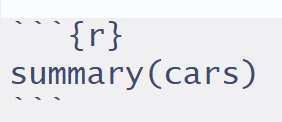

- 執行結果

```r
summary(cars)
```

```
##      speed           dist
##  Min.   : 4.0   Min.   :  2.00
##  1st Qu.:12.0   1st Qu.: 26.00
##  Median :15.0   Median : 36.00
##  Mean   :15.4   Mean   : 42.98
##  3rd Qu.:19.0   3rd Qu.: 56.00
##  Max.   :25.0   Max.   :120.00
```

### (4).常用 Chunk Options

- 常用 Chunk Options 使用說明表

| 選項 | 功能 |
| --- | --- |
| `echo = TRUE/FALSE` | 是否顯示 R 程式碼，TRUE顯示 |
| `eval = TRUE/FALSE` | 是否執行程式碼 |
| `include = TRUE/FALSE` | 是否將程式碼與結果放入文件 |
| `message = FALSE` | 隱藏套件訊息 |
| `warning = FALSE` | 隱藏警告訊息 |
| `fig.width` | 圖形寬度 |
| `fig.height` | 圖形高度 |
| `fig.cap` | 圖形標題 |

- 範例：只顯示執行結果，不顯示程式碼，使用`, echo=FALSE`。

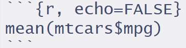

- 範例：執行結果沒有R程式碼。

```
## [1] 20.09062
```

### (5).文字內嵌R程式執行結果（Inline R Code）

R Markdown 可以直接將計算結果放入文字中，這種方式可以避免人工複製數值造成錯誤。

範例1：文字中加入資料筆數。

```markdown
mtcars 資料共有 32 筆資料。
```

範例2：文字中加入資料筆數。

`mtcars` 資料共有 **32** 筆資料，平均 MPG 為 **20.09**。

## 3.HTML、PDF 與 Word

R Markdown 常見輸出格式：html_document、pdf_document、word_document。

```yaml
output:
  html_document: default
```

```yaml
output:
  pdf_document: default
```

```yaml
output:
  word_document: default
```

若需同時支援 HTML 與 PDF：

```yaml
output:
  html_document:
    toc: true
  pdf_document:
    toc: true
    latex_engine: xelatex
```

> PDF 需要 LaTeX 環境。若電腦尚未安裝，可考慮 `tinytex::install_tinytex()`。中文字型問題可以使用 XeLaTeX 軟體處理。

> PDF中文字型處理 YouTube：https://youtu.be/6Wc75BH02iE

> RMarkdown Chinese Font PDF: https://rwepa.blogspot.com/2024/09/rmarkdown-chinese-font-pdf.html

## 4.Quarto 簡介

- Quarto 是一套由 Posit 推出的開放原始碼文件出版系統（scientific and technical publishing system），主要用來將「文字、程式碼、分析結果與圖表」整合成可重現的文件。
- Quarto 是新一代的科學與技術出版工具，支援 R、Python、Julia 等語言。
- 如果你已經熟悉 R Markdown，可以把 Quarto 理解成：

> Quarto = 新一代、跨語言的 R Markdown 文件系統。
- Quarto 檔案的副檔名為 `.qmd`。
- Quarto - YAML 格式為 `format: html`。
- Quarto開建立新檔案 > RStudio File New File Quarto Document
- Quarto 官網：https://quarto.org/
- 課程中先掌握 R Markdown 核心概念，未來轉換到 Quarto 時，報告結構、Markdown 與程式區塊觀念大致相同。
- 課堂練習

請建立一份 R Markdown，完成：

1. 標題：「我的第一份可重現報告」。
2. 顯示目前日期。
3. 使用 `summary(mtcars)` 顯示摘要。
4. 使用 `ggplot2` 畫出 `wt` 與 `mpg` 的散佈圖。
5. 輸出 HTML。

參考：

- 系統日期 `Sys.Date()`

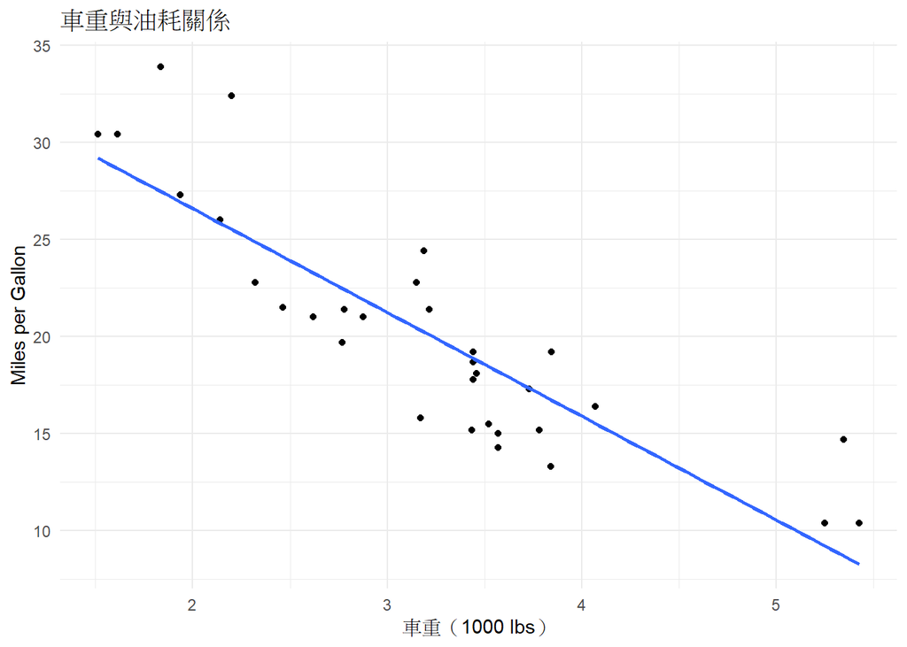

```r
library(ggplot2)
ggplot(mtcars, aes(x = wt, y = mpg)) +
  geom_point() +
  geom_smooth(method = "lm",  formula = 'y ~ x', se = FALSE) +
  labs(
    title = "車重與油耗關係",
    x = "車重（1000 lbs）",
    y = "Miles per Gallon"
  ) +
  theme_minimal()
```

# 🌸 5.2 參數化報告與自動化輸出（HTML/PDF）

## 1.為什麼需要參數化？

假設同一份報告需要產生：

- 不同月份報告。
- 不同部門報告。
- 不同地區報告。
- 不同產品報告。

如果每次都複製一份 `.Rmd` 再修改條件，容易造成版本混亂。

較好的方式是：

> 保留一份報告模板，將會變動的條件設定為 `params`。

## 2.YAML 中設定參數

在 YAML 最上方已設定：

```yaml
params:
  analyst: "學員姓名"
  department: "資料分析組"
  report_date: "2026-09-06"
  ozone_threshold: 60
```

在 R 程式中可使用：

```r
params$analyst
params$department
params$report_date
params$ozone_threshold
```

目前參數：

[output not shown]

## 3.使用參數控制分析條件

以下使用內建 `airquality` 資料集示範。

```r
library(knitr)
library(tidyverse)
aq <- airquality %>%
  mutate(
    Date = as.Date(sprintf("1973-%02d-%02d", Month, Day)),
    Ozone_Level = case_when(
      is.na(Ozone) ~ "Missing",
      Ozone >= params$ozone_threshold ~ "High",
      TRUE ~ "Normal"
    )
  )

head(aq)
```

|  | Ozone | Solar.R | Wind | Temp | Month | Day | Date | Ozone_Level |
| --- | --- | --- | --- | --- | --- | --- | --- | --- |
| 1 | 41 | 190 | 7.4 | 67 | 5 | 1 | 1973-05-01 | Normal |
| 2 | 36 | 118 | 8.0 | 72 | 5 | 2 | 1973-05-02 | Normal |
| 3 | 12 | 149 | 12.6 | 74 | 5 | 3 | 1973-05-03 | Normal |
| 4 | 18 | 313 | 11.5 | 62 | 5 | 4 | 1973-05-04 | Normal |
| 5 | NA | NA | 14.3 | 56 | 5 | 5 | 1973-05-05 | Missing |
| 6 | 28 | NA | 14.9 | 66 | 5 | 6 | 1973-05-06 | Normal |

依參數 `ozone_threshold = 60`，建立 High / Normal 分組。

```r
aq %>%
  filter(!is.na(Ozone)) %>%
  count(Ozone_Level) %>%
  mutate(Percentage = round(n / sum(n) * 100, 1)) %>%
  kable(
    col.names = c("Ozone 分組", "筆數", "百分比 (%)"),
    caption = "依參數門檻值建立的 Ozone 分組"
  )
```

依參數門檻值建立的 Ozone 分組

| Ozone 分組 | 筆數 | 百分比 (%) |
| --- | --- | --- |
| High | 31 | 26.7 |
| Normal | 85 | 73.3 |

## 4.使用 `rmarkdown::render()` 自動輸出

單次輸出：

```r
rmarkdown::render(
  input = "capstone_reproducible_report_3hr.Rmd",
  output_format = "html_document",
  params = list(
    analyst = "王小明",
    department = "北區營運部",
    report_month = "2026-08",
    ozone_threshold = 60
  ),
  output_file = "report_north_2026-08.html"
)
```

輸出 PDF：

```r
rmarkdown::render(
  input = "capstone_reproducible_report_3hr.Rmd",
  output_format = "pdf_document",
  params = list(
    analyst = "王小明",
    department = "北區營運部",
    report_month = "2026-08",
    ozone_threshold = 60
  ),
  output_file = "report_north_2026-08.pdf"
)
```

## 5.批次產生多份報告

```r
departments <- c("北區", "中區", "南區")

for (dept in departments) {
  rmarkdown::render(
    input = "report_template.Rmd",
    output_format = "html_document",
    params = list(
      department = dept,
      report_month = "2026-08"
    ),
    output_file = paste0("report_", dept, "_2026-08.html")
  )
}
```

> 參數化輸出的專業範例— RWEPA | shiny企業實務應用 第6集-小明算命師(下 ) 中文字幕
- YouTube 中文字幕: https://youtu.be/rrD6KV3eV-w
- LINK: https://rwepa.blogspot.com/2023/03/r-shiny-06-hr-teller.html
- Slide: https://rwepa.quarto.pub/r-shiny-06-hr-teller/
- Code: https://github.com/rwepa/business_analytics/tree/main/r-shiny-06-hr-teller
- Rmd 參數化範例: https://github.com/rwepa/business_analytics/tree/main/r-shiny-06-hr-teller/r-code/data

> RWEPA | shiny企業實務應用 第1集-白話shiny
- YouTube: https://youtu.be/NV7WNjccfxs
- LINK: https://rwepa.blogspot.com/2023/01/r-shiny-01-introduction.html
- Slide: https://rwepa.quarto.pub/r-shiny-01-introduction/
- Code: https://github.com/rwepa/business_analytics/tree/main/r-shiny-01-introduction

# 🌸 5.3 專題題目設計：指標定義、資料流程、視覺化呈現

## 1.好的專題從「問題」開始

不要一開始就問：

> 我要畫什麼圖？

應先問：

> 我要回答什麼問題？

一個小型分析專題可以採用以下結構：

```
Business Question
      ↓
指標 KPI
      ↓
需要哪些資料？
      ↓
資料整理與品質檢查
      ↓
分析 / 比較
      ↓
視覺化
      ↓
洞察與建議
```

## 2.題目設計範例

### 題目 A：空氣品質與溫度關係

研究問題：

> 高溫是否伴隨較高的臭氧濃度？

主要指標：

- 平均 Ozone
- 平均 Temp
- 高 Ozone 天數
- Ozone 與 Temp 的相關程度

### 題目 B：汽車油耗分析

資料：`mtcars`

研究問題：

> 車重、汽缸數與油耗之間有什麼關係？

主要指標：

- 平均 MPG
- 各汽缸數平均 MPG
- 車重與 MPG 關係

### 題目 C：鳶尾花分類特徵

資料：`iris`

研究問題：

> 三種 Species 在花瓣長度與寬度上是否存在明顯差異？

主要指標：

- 各 Species 平均 Petal.Length
- 各 Species 平均 Petal.Width
- 分布差異

## 3.KPI / 指標定義表

建立報告前先定義指標：

| 指標 | 定義 | 計算方式 | 用途 |
| --- | --- | --- | --- |
| 平均 Ozone | 有效 Ozone 值平均 | `mean(Ozone, na.rm=TRUE)` | 描述整體空氣品質 |
| 高 Ozone 天數 | Ozone ≥ 門檻值 | `sum(Ozone >= threshold)` | 找出高污染日 |
| 平均溫度 | Temp 平均 | `mean(Temp)` | 描述氣溫 |
| 相關係數 | Temp 與 Ozone 線性相關 | `cor()` | 評估變數關係 |

### 指標定義的三個原則

1. **可計算**：能從現有資料欄位算出。
2. **可解釋**：使用者知道數值代表什麼。
3. **可行動**：指標變化可以支持決策或後續分析。

## 4.資料流程設計

建議將程式依功能分成數個步驟：

```
01. Import
02. Clean
03. Transform
04. Summarise
05. Visualise
06. Interpret
07. Export
```

R 範例：

```r
analysis_data <- airquality %>%
  filter(!is.na(Ozone), !is.na(Temp)) %>%
  mutate(
    Month = factor(Month),
    High_Ozone = Ozone >= params$ozone_threshold
  )

monthly_summary <- analysis_data %>%
  group_by(Month) %>%
  summarise(
    Days = n(),
    Avg_Ozone = mean(Ozone),
    Avg_Temp = mean(Temp),
    High_Ozone_Days = sum(High_Ozone),
    .groups = "drop"
  )

monthly_summary %>%
  kable(digits = 1, caption = "月份指標摘要")
```

月份指標摘要

| Month | Days | Avg_Ozone | Avg_Temp | High_Ozone_Days |
| --- | --- | --- | --- | --- |
| 5 | 26 | 23.6 | 66.7 | 1 |
| 6 | 9 | 29.4 | 78.2 | 1 |
| 7 | 26 | 59.1 | 83.9 | 13 |
| 8 | 26 | 60.0 | 84.0 | 12 |
| 9 | 29 | 31.4 | 76.9 | 4 |

## 5.視覺化並回答問題

### 圖1 比較各月份平均 Ozone

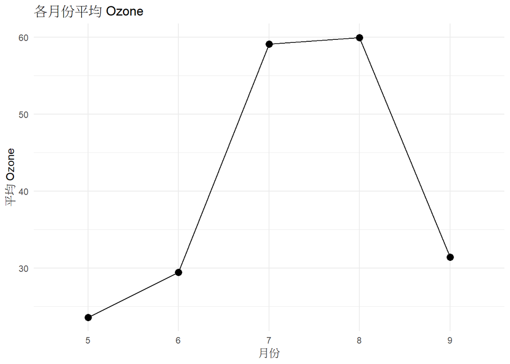

各月份平均 Ozone

```r
ggplot(monthly_summary, aes(x = Month, y = Avg_Ozone, group = 1)) +
  geom_line() +
  geom_point(size = 3) +
  labs(
    title = "各月份平均 Ozone",
    x = "月份",
    y = "平均 Ozone"
  ) +
  theme_minimal()
```

### 圖2 Temp 與 Ozone 關係圖

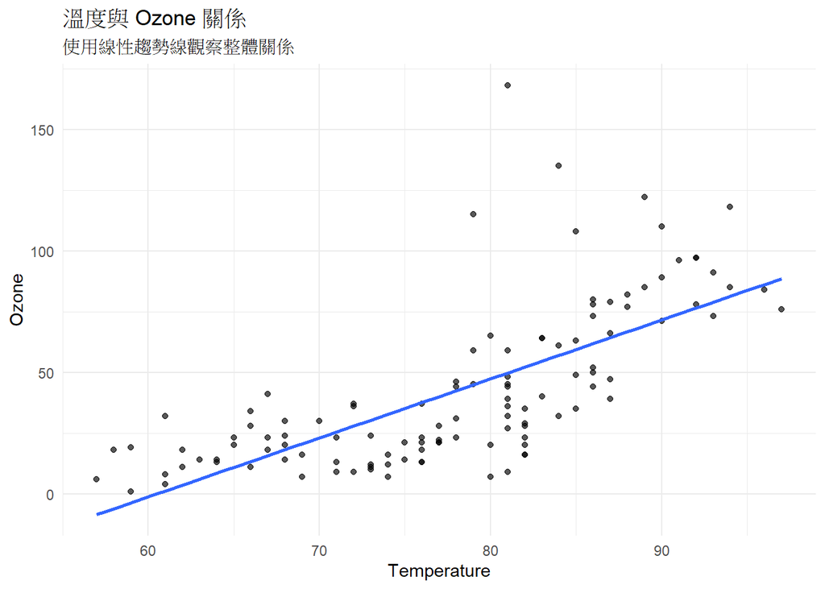

溫度與 Ozone 關係

```r
ggplot(analysis_data, aes(x = Temp, y = Ozone)) +
  geom_point(alpha = 0.65) +
  geom_smooth(method = "lm", formula = 'y ~ x', se = FALSE) +
  labs(
    title = "溫度與 Ozone 關係",
    subtitle = "使用線性趨勢線觀察整體關係",
    x = "Temperature",
    y = "Ozone"
  ) +
  theme_minimal()
```

- 從圖表寫出「洞察力」

一段完整的分析敘述，建議包含：**發現 → 證據 → 解釋 → 建議**

範例：

> 資料顯示溫度較高時 Ozone 整體也有上升趨勢。散佈圖中的線性趨勢線呈正向，表示兩者可能具有正相關。實務上可進一步納入風速、月份等變數，以判斷溫度是否仍具有獨立解釋力。

避免只寫：

> 圖中可以看到 Ozone 有變化。

# 🌸 5.4 分組/個人實作：完成小型分析專題

- 2026年資料集願望清單: https://github.com/rwepa/r_data_scientist/blob/main/hands-on_introduction_to_r_2026/2026_Dataset_Wishlist.md

# 🌸 5.5 成果發表與回饋：同儕審閱、改版清單

- 鼓勵學員成果發表與回饋。

[figure not shown]

[figure not shown]